# C.E.A.P Analysis

Exploratory data analysis on ‘Quota for the exercise of parliamentary activity’ provided by the Brazilian government

José Benardi de Souza Nunes

30/08/2018

# Introduction

> This exploratory data analysis was made based on data provided by the Brazilian government about the expenses allowed to its parliamentarians or C.E.A.P. (Cota para o Exercício da Atividade Parlamentar / Quota for the Exercise of Parliamentary Activity). More information about it (in Portuguese) can be found in its [official site](http://www2.camara.leg.br/transparencia/acesso-a-informacao/copy_of_perguntas-frequentes/cota-para-o-exercicio-da-atividade-parlamentar)

# Data Overview

```r
data <- read_csv(here::here("data/dadosCEAP.csv"),
                 progress = F,
                 col_types = cols(
                   nomeParlamentar = col_character(),
                   idCadastro = col_integer(),
                   sgUF = col_character(),
                   sgPartido = col_character(),
                   tipoDespesa = col_character(),
                   especDespesa = col_character(),
                   fornecedor = col_character(),
                   CNPJCPF = col_character(),
                   tipoDocumento = col_integer(),
                   dataEmissao = col_character(),
                   valorDocumento = col_double(),
                   valorGlosa = col_integer(),
                   valorLíquido = col_double()))

data %>%
  mutate(dataEmissao = parse_date_time(dataEmissao,"%Y-%m-%d %H:%M:%S"),
         year_month = paste(lubridate::year(dataEmissao),   # extract year
                            lubridate::month(dataEmissao),  # extract month
                            sep = "-"),
         tipoDespesa = toupper(tipoDespesa)) -> data

state_info <- read_csv(here::here("/data/limiteMensalCEAP.csv"),
                       progress = F,
                       col_types = cols(
                         UF = col_character(),
                         limite_mensal = col_double()))

data %>%
  full_join(state_info,
            by = c("sgUF" = "UF")) -> data

data %>%
  glimpse()
```

```
## Observations: 963,452
## Variables: 15
## $ nomeParlamentar <chr> "ABEL MESQUITA JR.", "ABEL MESQUITA JR.", "ABE...
## $ idCadastro      <int> 178957, 178957, 178957, 178957, 178957, 178957...
## $ sgUF            <chr> "RR", "RR", "RR", "RR", "RR", "RR", "RR", "RR"...
## $ sgPartido       <chr> "DEM", "DEM", "DEM", "DEM", "DEM", "DEM", "DEM...
## $ tipoDespesa     <chr> "MANUTENÇÃO DE ESCRITÓRIO DE APOIO À ATIVIDADE...
## $ especDespesa    <chr> NA, NA, NA, NA, NA, "Veículos Automotores", "V...
## $ fornecedor      <chr> "COMPANHIA DE AGUAS E ESGOTOS DE RORAIMA", "CO...
## $ CNPJCPF         <chr> "05939467000115", "05939467000115", "023414700...
## $ tipoDocumento   <int> 0, 0, 0, 0, 0, 0, 0, 0, 0, 0, 0, 0, 0, 0, 0, 0...
## $ dataEmissao     <dttm> 2015-11-14, 2015-12-10, 2015-11-27, 2015-12-3...
## $ valorDocumento  <dbl> 165.65, 59.48, 130.95, 196.53, 310.25, 32.00, ...
## $ valorGlosa      <int> 0, 0, 0, 347, 0, 0, 0, 0, 0, 0, 0, 0, 0, 0, 0,...
## $ valorLíquido    <dbl> 165.65, 59.48, 130.95, 193.06, 310.25, 32.00, ...
## $ year_month      <chr> "2015-11", "2015-12", "2015-11", "2015-12", "2...
## $ limite_mensal   <dbl> 45612.53, 45612.53, 45612.53, 45612.53, 45612....
```

```r
read_tsv(here::here("data/trsl_expenses.tsv"),
         progress = F,
         col_types = cols(
           original_term = col_character(),
           translation = col_character())) -> trsltd_expenses

trsltd_expenses
```

| original_term | translation |
| --- | --- |
| MANUTENÇÃO DE ESCRITÓRIO DE APOIO À ATIVIDADE PARLAMENTAR | MAINTENANCE OF OFFICE TO SUPPORT PARLIAMENTARY ACTIVITY |
| COMBUSTÍVEIS E LUBRIFICANTES. | FUELS AND LUBRICANTS. |
| CONSULTORIAS, PESQUISAS E TRABALHOS TÉCNICOS. | CONSULTANCIES, RESEARCH AND TECHNICAL WORKS. |
| DIVULGAÇÃO DA ATIVIDADE PARLAMENTAR. | DIVULGATION OF PARLIAMENTARY ACTIVITY. |
| SERVIÇO DE SEGURANÇA PRESTADO POR EMPRESA ESPECIALIZADA. | SECURITY SERVICE PROVIDED BY SPECIALIZED COMPANY. |
| PASSAGENS AÉREAS | AIRLINE TICKETS |
| SERVIÇOS POSTAIS | POSTAL SERVICES |
| FORNECIMENTO DE ALIMENTAÇÃO DO PARLAMENTAR | SUPPLY OF FOOD FOR PARLIAMENTARIAN |
| TELEFONIA | TELEPHONY |
| LOCAÇÃO OU FRETAMENTO DE VEÍCULOS AUTOMOTORES | LEASING OR FREIGHTING OF AUTOMOTIVE VEHICLES |

[output cut: 8 more lines]

- A translation for the description of each one of the 18 types of expense was recorded alongside its original term.

```r
data %>%
  full_join(trsltd_expenses,
            by = c("tipoDespesa" = "original_term"))  %>%
  mutate(tipoDespesa = translation) %>%  # translate col tipoDespesa
  select(-translation)-> data # drop unused column

data %>%
  sample_n(5) %>%
  select(nomeParlamentar,
         tipoDespesa,
         dataEmissao)
```

| nomeParlamentar | tipoDespesa | dataEmissao |
| --- | --- | --- |
| PAULO TEIXEIRA | TAXI SERVICE, TOLL AND PARKING | 2017-08-22 |
| VICENTE ARRUDA | FUELS AND LUBRICANTS. | 2016-08-25 |
| PEPE VARGAS | TAXI SERVICE, TOLL AND PARKING | 2016-05-19 |
| ZECA DIRCEU | SUPPLY OF FOOD FOR PARLIAMENTARIAN | 2015-01-27 |
| PAULÃO | SUPPLY OF FOOD FOR PARLIAMENTARIAN | 2016-12-19 |

- We now have each term in the column tipoDespesa translated.

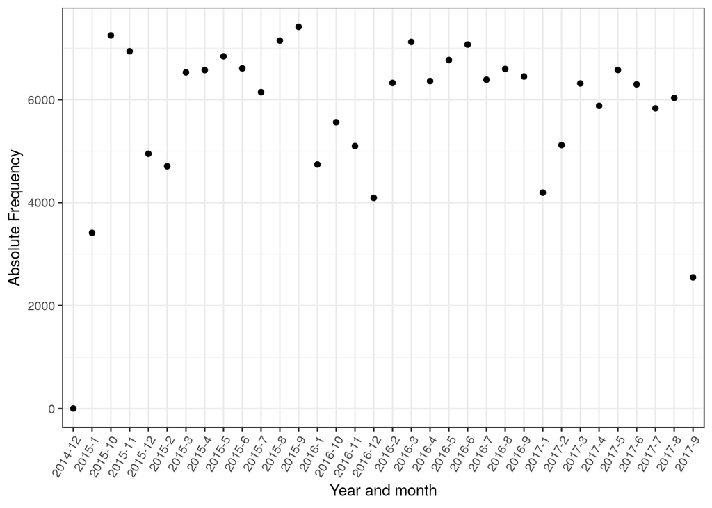

```r
data %>%
  na.omit(year_month) %>%
  group_by(year_month) %>%     # times used
  summarize(total = n()) %>%   # by year/month
  ggplot(aes(year_month, total)) +
  geom_point() +
  theme(axis.text.x = element_text(angle = 60,
                                   hjust = 1)) +
  labs(x="Year and month", y="Absolute Frequency")
```

- The period of time covered by the dataset is of about 3 years which amounts to the duration of our parliamentarian’s office minus the 120 days prior to the election.

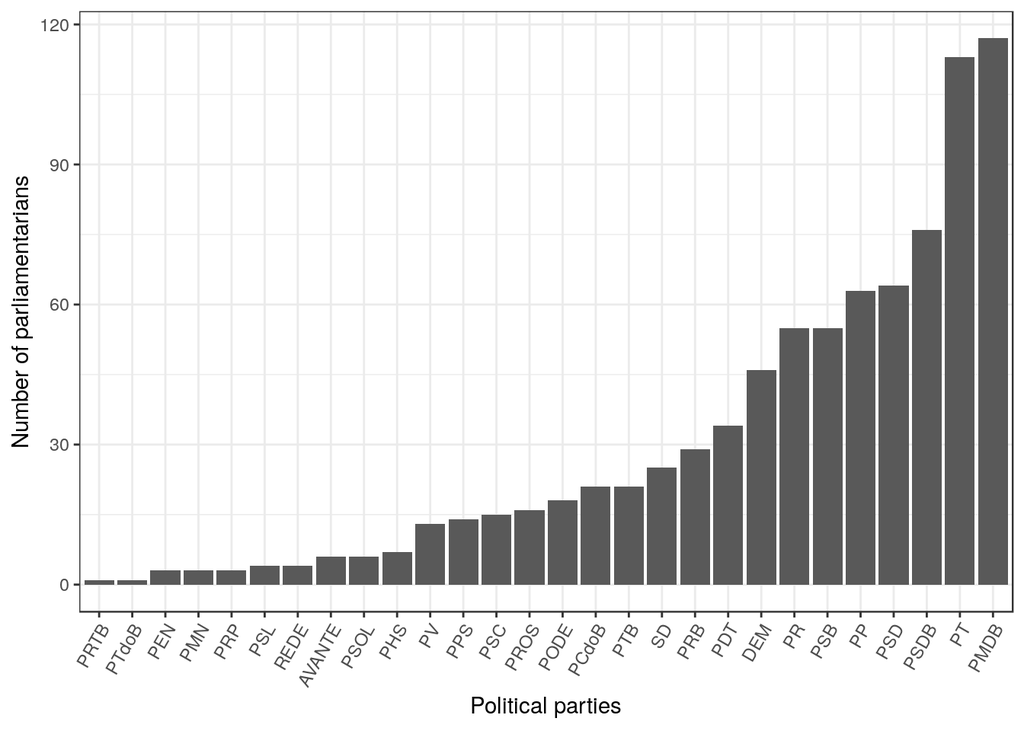

```r
data %>%
  group_by(idCadastro,
           nomeParlamentar) %>%
  slice(1) %>% # keep one entry for parliamentarian
  ungroup() %>%
  group_by(sgPartido) %>%              # calc parliamentarian
  summarize(num_parliament = n()) %>%  # by party
  na.omit() %>%
  ggplot(aes(reorder(sgPartido,
                     num_parliament),
             num_parliament)) +
  geom_bar(stat="identity") +
  labs(x="Political parties",
       y="Number of parliamentarians") +
  theme(axis.text.x = element_text(angle = 60,
                                   hjust = 1))
```

- We can see that **PMDB** detains the majority of offices followed closely by **PT** and that **PSDB** is still a major player. This was to be expected as the aforementioned parties are often regarded as the most proeminent ones in the Brazilian political scene.

# Overall spending of the CEAP budget

##### In this section we’ll look at both the **biggest spenders** and **most frugal** parliamentarians.

##### We’ll examine each group in ranks of 10 parliamentarians, a commonplace in terms of ranking.

## Which parliamentarians spent the most?

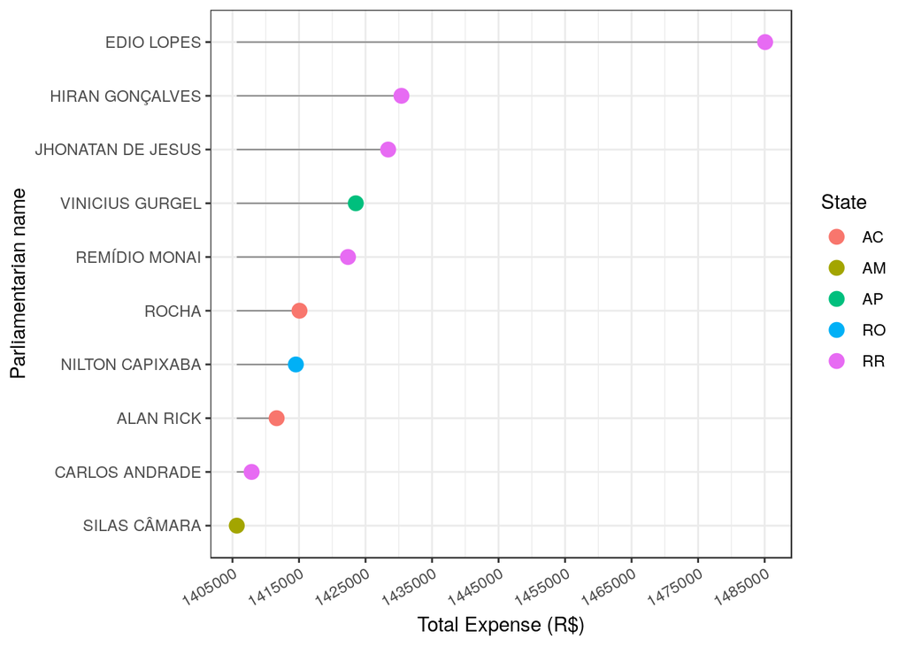

```r
data %>%
  group_by(sgUF,idCadastro,nomeParlamentar) %>%     # calculate expense for
  summarize(total_expense = sum(valorLíquido)) %>%  # each parliamentarian
  ungroup() %>%
  top_n(n=10, wt=total_expense) %>%  # get the top 10 expenders
  ggplot(aes(total_expense,
             reorder(nomeParlamentar,
                     total_expense))) +
  geom_segment(aes(x = min(total_expense),
                   y =reorder(nomeParlamentar,
                              total_expense),
                   xend = total_expense,
                   yend = nomeParlamentar),
               color = "grey50", size=0.35) +
  geom_point(aes(color=sgUF), size=3.5) +
  scale_x_continuous(breaks = seq(from = 135E3,
                                  to=1E7,
                                  by = 1E4)) +
  theme(axis.text.x = element_text(angle = 30,
                                   hjust = 1)) +
  guides(color=guide_legend("State")) +
  labs(x="Total Expense (R$)",
       y="Parliamentarian name")
```

- The parliamentarian *Edio Lopes* from the state of Roraima is the biggest spender with a total expense of $R\$\:1,\!485,\!000.\,00$ (that’s almost **1.5 million reais**).
  - *Edio Lopes* spent what the second place *Hiran Gonçalves* (also from Roraima) spent plus some $R\$\:55,\!000.\,00$.
  - *Edio Lopes* spent what the tenth place *Silas Câmara* from the state of Amazonas spent plus some $R\$\: 80,\!000.\,00$.
- All 10 parliamentarians spent well over *1 million reais*, furthermore except for Amazonas none of the states involved are usually pointed as one of the richest Brazilian states.
  - Among the states that made to the rank Amazonas would be the most prominent and yet its parliamentarian is right at the bottom of the top 10 rank.
- Half of the big spenders are from the state of Roraima (top three included).

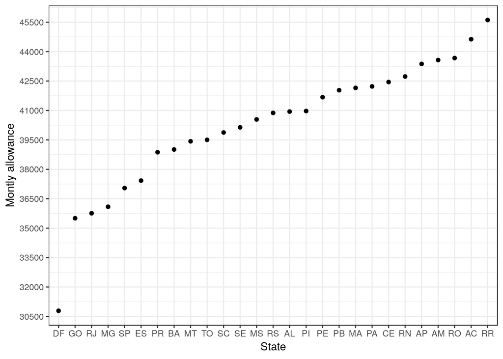

```r
state_info %>%
  ggplot(aes(reorder(UF,limite_mensal),
             limite_mensal)) +
  geom_point() +
  scale_y_continuous(breaks = seq(5E2,5E5,1.5E3)) +
  labs(y="Montly allowance", x="State")
```

- The state of Roraima (RR) has the biggest monthly allowance in the whole country which is approximately $R\$\:45,\!500.\,00$. It makes sense that their parliamentarians are among the biggest spenders in the whole country.
- The federal district (DF), where’s the capital, has the smallest allowance which is a little more than $R\$\:30,\!500.\,00$. A parliamentarian who lives there is already close to the capital so doesn’t have to travel by plane and probably already has a house there, so the smaller allowance is to be expected.

## Which parliamentarians spent less?

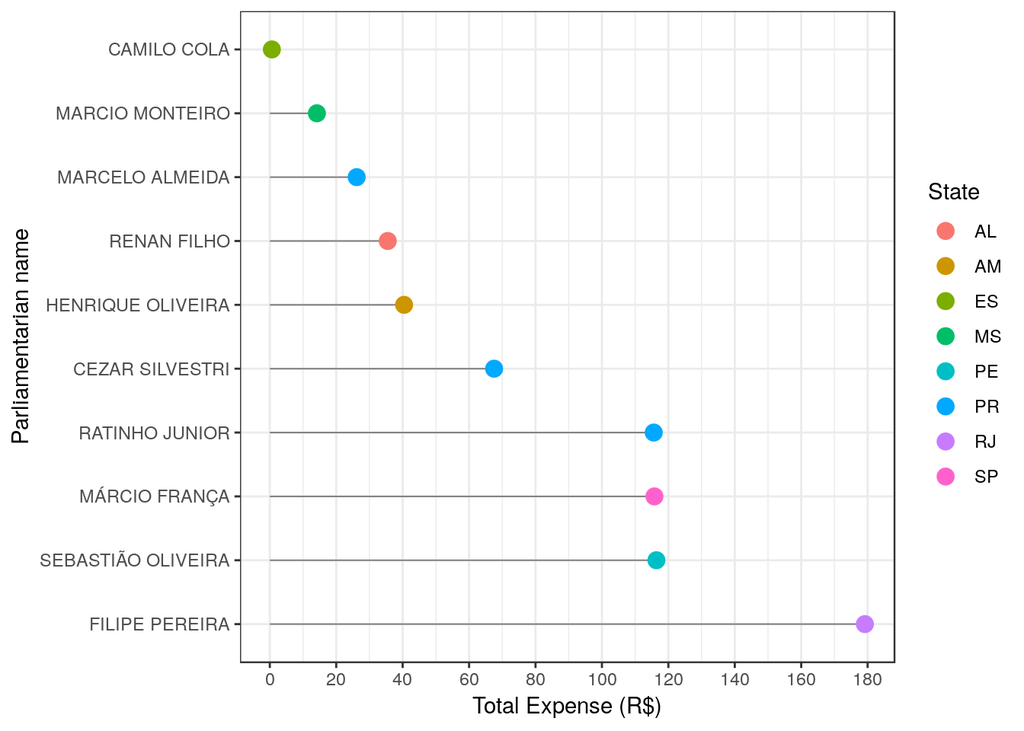

```r
data %>%
  group_by(sgUF,idCadastro,nomeParlamentar) %>%     # calculate expense for
  summarize(total_expense = sum(valorLíquido)) %>%  # each parliamentarian
  ungroup() %>%
  filter(total_expense >= 0) %>%  # Remove those without actual net amount
  arrange(total_expense) %>%      # Order by total expense
  slice(1:10) %>%                 # Get the top 10 frugal
  ggplot(aes(total_expense,
             reorder(nomeParlamentar,
                     total_expense))) +
  geom_segment(aes(x = 0,
                   y = reorder(nomeParlamentar,
                               -total_expense),
                   xend = total_expense,
                   yend = nomeParlamentar),
               color = "grey50", size=0.35) +
  geom_point(aes(color=sgUF), size=3.5) +
  scale_x_continuous(breaks = seq(from = 0,
                                  to=1E5,
                                  by = 20)) +
  guides(color=guide_legend("State")) +
  labs(x="Total Expense (R$)",
       y="Parliamentarian name")
```

Going against what one would expect none of the more frugal parliamentarians are from the Federal District (DF) which has the smallest monthly allowance.

- Our frugal friends live in other states so they had to travel and pay for accommodations. So, how did they pay for the aforementioned expenses? Did it come from their own pockets?
  - The parliamentarian *Camilo Cola* spent a astonishingly small sum, this demands a closer look.

### A closer look at the 3 most frugal parliamentarians in Brazil

Let’s look at the exact values for the top 3 most frugal parliamentarians

```r
data %>%
  group_by(sgUF,idCadastro,nomeParlamentar) %>%
  summarize(total_expense = sum(valorLíquido)) %>%
  ungroup() %>%
  filter(total_expense >= 0) %>%
  arrange(total_expense) %>%
  slice(1:3)
```

| sgUF | idCadastro | nomeParlamentar | total_expense |
| --- | --- | --- | --- |
| ES | 141395 | CAMILO COLA | 0.62 |
| MS | 178899 | MARCIO MONTEIRO | 14.18 |
| PR | 146613 | MARCELO ALMEIDA | 26.16 |

- The total expense of the top 3, specially Camilo Cola who spent only $R\$\:0.\,62$ seems almost ludicrous.

```r
data %>%
  select(sgUF,fornecedor,
         nomeParlamentar,
         sgPartido,tipoDespesa) %>%
  filter(nomeParlamentar %in%
         c("CAMILO COLA",
           "MARCIO MONTEIRO",
           "MARCELO ALMEIDA"))
```

| sgUF | fornecedor | nomeParlamentar | sgPartido | tipoDespesa |
| --- | --- | --- | --- | --- |
| ES | RAMAL | CAMILO COLA | PMDB | TELEPHONY |
| PR | RAMAL | MARCELO ALMEIDA | PMDB | TELEPHONY |
| MS | RAMAL | MARCIO MONTEIRO | PSDB | TELEPHONY |

- The only expense of each of the 3 parliamentarians was related to telephony. Most likely something they couldn’t pay for themselves in reason of bureaucracy.

#### Camilo Cola

##### Looking up the most frugal parliamentarians in Brazil we can have an idea of who he is. Originally very poor, **Camilo Cola** is a self made businessman and founder of a whole bussiness empire called Grupo Itapemirim. When **Camilo** first became a parliamentarian he was over 80 years old.

> Camilo Cola seems the type of man that would pay for pretty much all of his expenses as parliamentarian.

#### Marcio Monteiro

# Looking at spending by state

##### In this section we’ll look at the parliamentary expenses paid for with the CEAP budget from the point of view of the states these parliamentarians represent.

##### When talking about the parliamentarians themselves we’ll keep our ranking of 10 parliamentarians. However, when examining the states we’ll adopt a **ranking of 3 states**. Talking about 10 states means talking about almost half the states, which would be cumbersome.

## Parliamentarians from which states spent the most abroad? And the less?

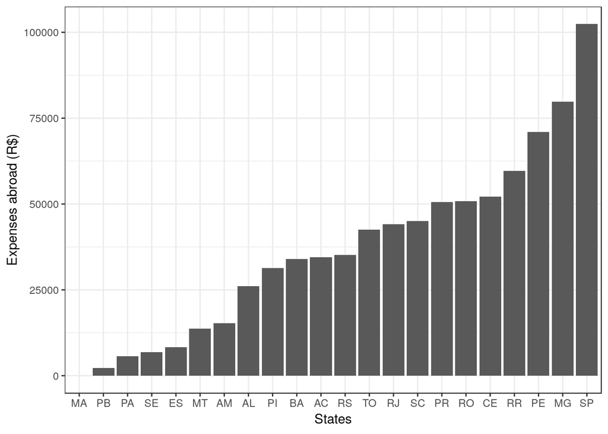

```r
data %>%
  filter(tipoDocumento == 2) %>%  # Keep only expenses abroad
  group_by(sgUF) %>%  # group by State
  summarize(international_expense = sum(valorLíquido)) %>% # calc expense by state
  ggplot(aes(reorder(sgUF,international_expense),
             international_expense)) +
  geom_bar(stat = "identity") +
  labs(x="States", y="Expenses abroad (R$)")
```

- Parliamentarians from Maranhão, Paraíba and Pará spent the less abroad.
  - The three states are less prominent (smaller gross domestic product for instance) so it makes sense their parliamentarians would spend less abroad.
  - Maranhão spendings are incredibly small, a closer look is due.
- Parliamentarians from São Paulo, Minas Gerais and Pernambuco spent the most abroad
  - São Paulo and Minas Gerais and in lesser degree Pernambuco are some of the richest states in Brazil.

```r
data %>%
  filter(tipoDocumento == 2) %>% # keep only expenses abroad
  filter(sgUF == "MA") %>%  # keep only expenses from MA
  select(fornecedor,
         tipoDespesa,
         valorLíquido,
         nomeParlamentar,
         sgUF,
         sgPartido)
```

| fornecedor | tipoDespesa | valorLíquido | nomeParlamentar | sgUF | sgPartido |
| --- | --- | --- | --- | --- | --- |
| 7 ELEVEN | SUPPLY OF FOOD FOR PARLIAMENTARIAN | 40.99 | JUNIOR MARRECA | MA | PEN |

- The whole international expense made by all the parliamentarians from the state of Maranhão was some meal bought at a convenience store. For the looks of the chain of convenience stores it was most likely fast food.

## Which parliamentarians violated the CEAP budget set by their state the most?

```r
data %>%
  group_by(sgUF,idCadastro,year_month,          # group by parliamentarian
           nomeParlamentar,limite_mensal) %>%   # and vars of interest
  summarise(monthly_expense = sum(valorLíquido)) %>% # calc expense by month/year
  filter(year_month != "NA-NA") %>%  # remove expense without a month/year
  filter(monthly_expense > limite_mensal) %>%  # keep only violations
  ungroup() -> expense_month_year
#
expense_month_year %>%
  select(nomeParlamentar,
         year_month,
         limite_mensal,
         monthly_expense) %>%
  sample_n(5)
```

| nomeParlamentar | year_month | limite_mensal | monthly_expense |
| --- | --- | --- | --- |
| CAPITÃO AUGUSTO | 2015-8 | 37043.53 | 41294.78 |
| MOEMA GRAMACHO | 2016-6 | 39010.85 | 50862.78 |
| CARLOS SAMPAIO | 2016-12 | 37043.53 | 53551.54 |
| GIUSEPPE VECCI | 2017-4 | 35507.06 | 38028.97 |
| TIA ERON | 2016-1 | 39010.85 | 42883.05 |

- We now have the monthly expense of the parliamentarians that violated their respective monthly allowance.

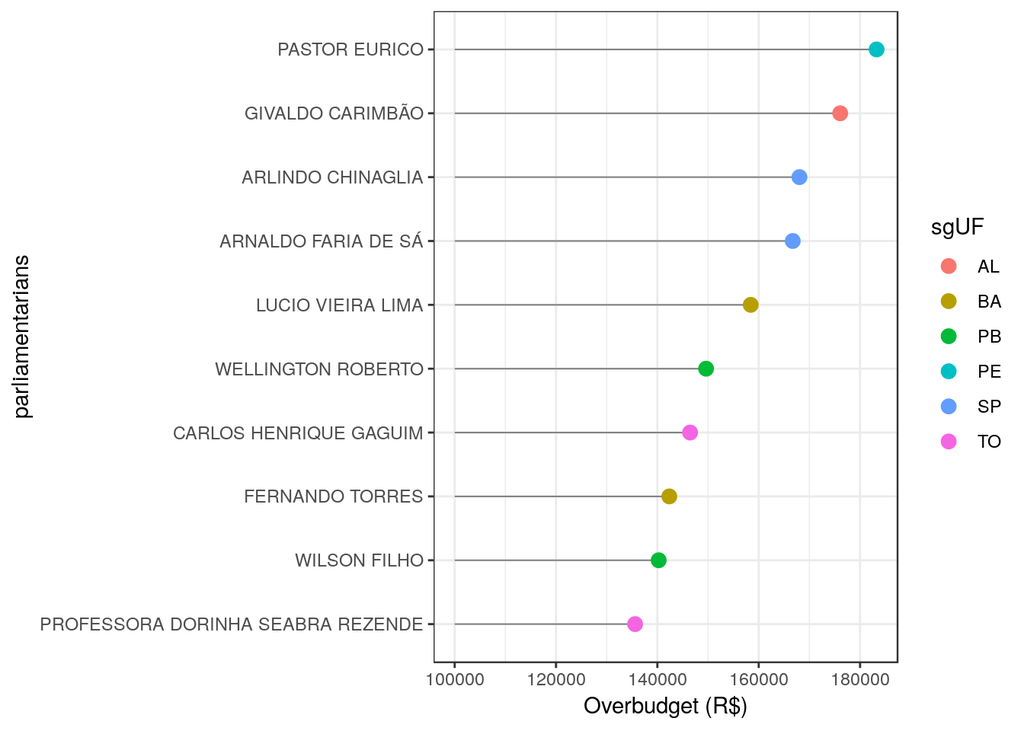

```r
expense_month_year %>%
  group_by(idCadastro,nomeParlamentar) %>% # group only by parliamentarian
  arrange(desc(monthly_expense)) %>%   # order by month/year expense
  slice(1) %>%                         # keep biggest expense of each parliamentarian
  ungroup() %>%
  top_n(n=10, wt=monthly_expense) %>%  # get overall top 10 month/year expenses
  mutate(overbudget = monthly_expense - limite_mensal) %>% # calc actual overbudget
  ggplot(aes(overbudget,
             reorder(nomeParlamentar,
                     overbudget))) +
  geom_segment(aes(x = 1E5,
                   y =reorder(nomeParlamentar,
                              overbudget),
                   xend = overbudget,
                   yend = nomeParlamentar),
               color = "grey50",
               size=0.35) +
  geom_point(aes(color=sgUF),size=3) +
  labs(x="Overbudget (R$)",
       y="parliamentarians")
```

- At the top of the rank we have Pastor Eurico who managed to spend over R$ 180,000 more than he should in a single month.
- All of our ranked parliamentarians for some reason had to spend way over R$ 100,000 than they should have in the period of a single month.

## At which states the parliamentarians spent the most with airfare ? And the less?

We will consider both the cost of air tickets themselves and the cost of their issuance.

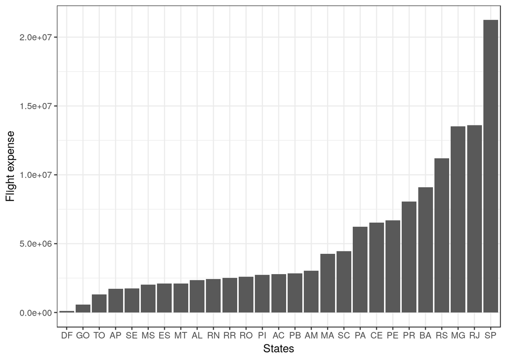

```r
data %>%
  filter(tipoDespesa %in%
         c("AIRLINE TICKETS",
           "AIR TICKET ISSUANCE")) %>% # keep only fligths
  group_by(sgUF) %>%
  summarize(international_expense = sum(valorLíquido)) %>%
  filter(sgUF != "NA") %>%
  ggplot(aes(reorder(sgUF,international_expense),
             international_expense)) +
  geom_bar(stat = "identity") +
  labs(x="States", y="Flight expense")
```

#### States where parliamentarians spent less with airfare

- We have Distrito Federal - **DF**, Goiás - **GO** and Tocantins - **TO**.
  - The capital is in Distrito Federal, so not a lot of reasons to fly around.
  - Distrito Federal is actually within the borders of Goiás and Tocantins is right next to Goiás itself.

# Taking a closer look at Paraíba

##### In this section we’ll pay closer attention to the state of Paraíba. We’ll examine which political parties are the most avid and the most restrained spenders in terms of frequency and overall cost.

##### We’ll put the political parties in **rankings of 3**, a number we consider reasonable as our examination covers a total of 12 political parties.

## In which parties the parliamentarians used CEAP more frequently? In which did they use it less frequently?

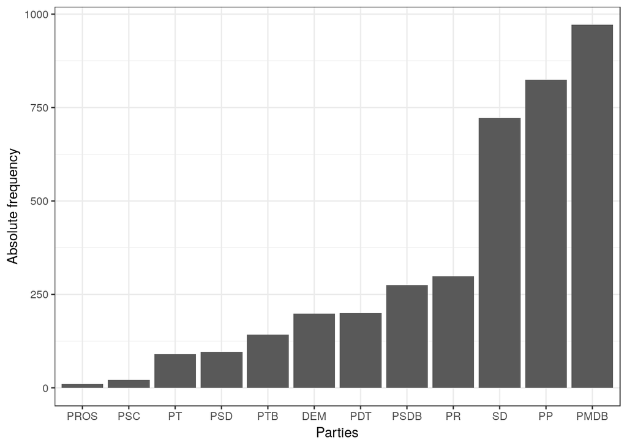

```r
data %>%
  filter(sgUF == "PB") %>% # keep only PB
  na.omit(sgUF,
          sgPartido) %>%
  group_by(sgPartido) %>%
  summarize(frequency =n()) %>% # calc num of times
  ggplot(aes(reorder(sgPartido,frequency),
             frequency)) +
  geom_bar(stat = "identity") +
  labs(x="Parties", y="Absolute frequency")
```

- The parties **PMDB** (Brazilian Democratic Movement | centre to centre-right), **PP** (Progressistas | right-wing) and **SD** (Solidariedade | centre-left) are by far the ones that used CEAP the most times.
  - In the case of **PMDB** it was to be expected as it detains the majority of offices.
- The parties **PSC** (Social Christian Party | centre-right) and **PROS** (Republican Party of the Social Order | centre-right) are by far the ones that have used CEAP the least times.
  - The third party to have used CEAP the least times **PT** (Workers’ Party | centre-left to left-wing) still used CEAP many times more than **PSC** and **PROS**.

## In which parties the parliamentarians spent the most from CEAP? In which they spent the less?

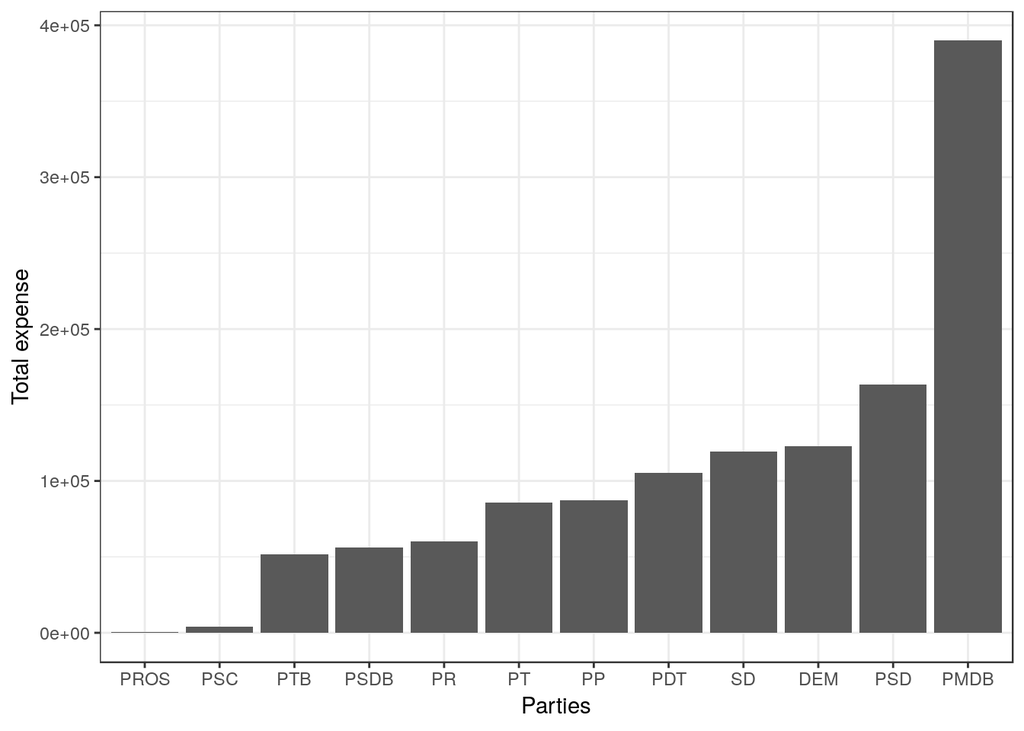

```r
data %>%
  filter(sgUF == "PB") %>% # keep only PB
  na.omit(sgUF,
          sgPartido,
          valorLíquido) %>%
  group_by(sgPartido) %>%
  summarize(total_expense = sum(valorLíquido)) %>% # calc total expense
  ggplot(aes(reorder(sgPartido,total_expense),
             total_expense)) +
  geom_bar(stat = "identity") +
  labs(x="Parties", y="Total expense")
```

- **PMDB** (Brazilian Democratic Movement | centre to centre-right) is by far the party that spent the most in Paraíba, which was to be expected as **PMDB** detains the majority of offices.
  - Second place **PSD** (Social Democratic Party | centre) and third place and **DEM** (Democrats | centre-right to right) total expenses are far below the biggest spender.
- The parties **PSC** (Social Christian Party | centre-right) and **PROS** (Republican Party of the Social Order | centre-right) both spent very little compared to the rest and are clearly the parties that spent less in Paraíba.
  - The third party to spend less **PTB** (Brazilian Labour Party | centre-right) still has a total expense considerably bigger than that of **PSC** and **PROS**.

# Looking at spending by political party

##### At this section we’ll look closely at the expenses of three of the major political parties in Brazil: **PT, PSDB** and **PMDB**. Candidates from **PT** and **PSDB** are often the competitors at the run-off election for presidency and **PMDB** often holds the parliamentary majority (as is the case in this dataset). These are only some of the evidences of the importance of the chosen parties in the Brazilian political scene.

## What type of expense is more frequently paid for with CEAP by parliamentarians of these parties?

### PSDB

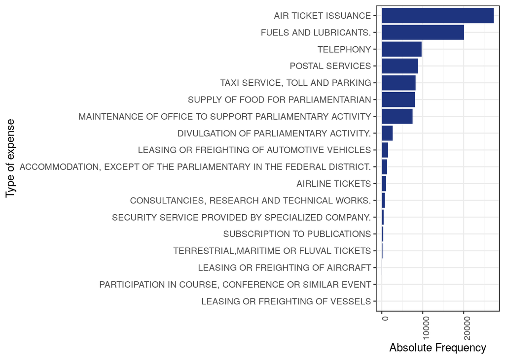

```r
data %>%
  filter(sgPartido %in% c("PSDB")) %>% # keep only PSDB
  group_by(tipoDespesa) %>%
  summarize(frequency = n()) %>% # calc total times
  ggplot(aes(reorder(tipoDespesa,frequency),
             frequency)) +
  geom_bar(stat="identity",
           fill="#1E347F") +
  labs(y= "Absolute Frequency",
       x="Type of expense") +
  coord_flip() +
  theme(axis.text.x = element_text(angle = 90,
                                   hjust = 1))
```

- **Air Tick Issuance** is the type of expense most frequently paid for with CEAP by parliamentarians from PSDB. Next follows **Fuel and Lubricants** and **Telephony**.

### PMDB

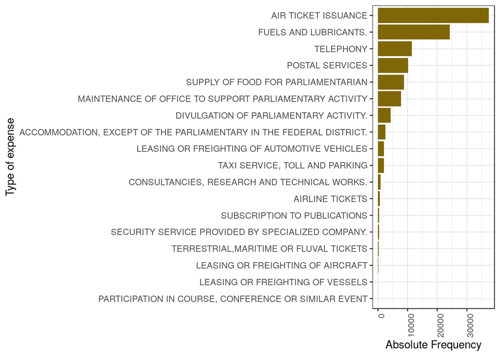

```r
data %>%
  filter(sgPartido %in% c("PMDB")) %>% # keep only PMDB
  group_by(tipoDespesa) %>%
  summarize(frequency = n()) %>% # calc total times
  ggplot(aes(reorder(tipoDespesa,frequency),
             frequency)) +
  geom_bar(stat="identity",
           fill="#7F6607") +
  labs(y= "Absolute Frequency",
       x="Type of expense") +
  coord_flip() +
  theme(axis.text.x = element_text(angle = 90,
                                   hjust = 1))
```

- **Air Tick Issuance** is the type of expense most frequently paid for with CEAP by parliamentarians from PMDB. Next follows **Fuel and Lubricants** and **Telephony**.

### PT

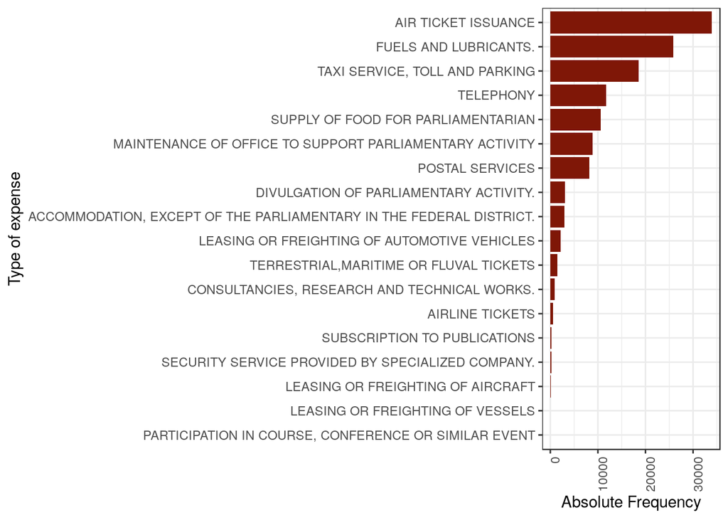

```r
data %>%
  filter(sgPartido %in% c("PT")) %>% # keep only PT
  group_by(tipoDespesa) %>%
  summarize(frequency = n()) %>% # calc total times
  ggplot(aes(reorder(tipoDespesa,frequency),
             frequency)) +
  geom_bar(stat="identity",
           fill="#7F1707") +
  labs(y= "Absolute Frequency",
       x="Type of expense") +
  coord_flip() +
  theme(axis.text.x = element_text(angle = 90,
                                   hjust = 1))
```

- **Air Tick Issuance** is the type of expense most frequently paid for with CEAP by parliamentarians from PT. Next follows **Fuel and Lubricants** and **Taxi Service, Toll and Parking**.

### Summary

> Across all three parties *the expense most frequently paid for with CEAP* is **Air Tick Issuance**, followed by **Fuel and Lubricants**. The third place is **Telephony** for PSDB and PMDB and **Taxi Service, Toll and Parking** for PT.

## What type of expense paid for with CEAP by parliamentarians of these parties costed more?

### PSDB

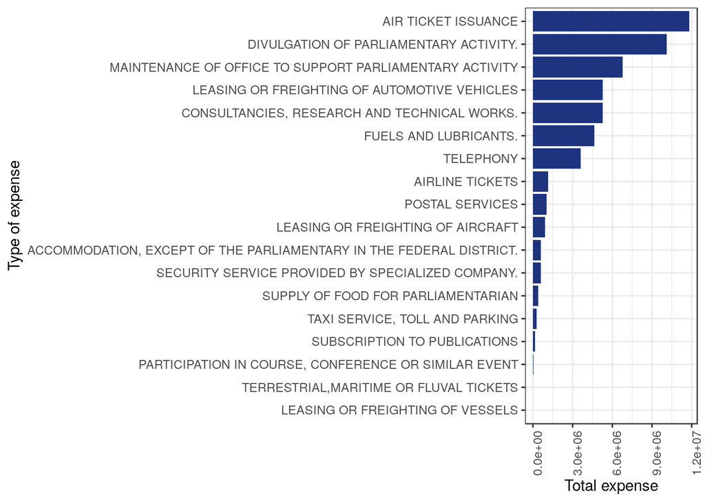

```r
data %>%
  filter(sgPartido %in% c("PSDB")) %>% # keep only PSDB
  group_by(tipoDespesa) %>%
  summarize(expense = sum(valorLíquido)) %>% # calc total expense
  ggplot(aes(reorder(tipoDespesa,expense),
             expense)) +
  geom_bar(stat="identity",
           fill="#1E347F") +
  labs(y= "Total expense",
       x="Type of expense") +
  coord_flip() +
  theme(axis.text.x = element_text(angle = 90,
                                   hjust = 1))
```

- The costlier expense for PSDB is **Air Tick Issuance** followed by **Divulgation of Parliamentary Activity** and **Maintenance of Office to support Parliamentary Activity**.

### PMDB

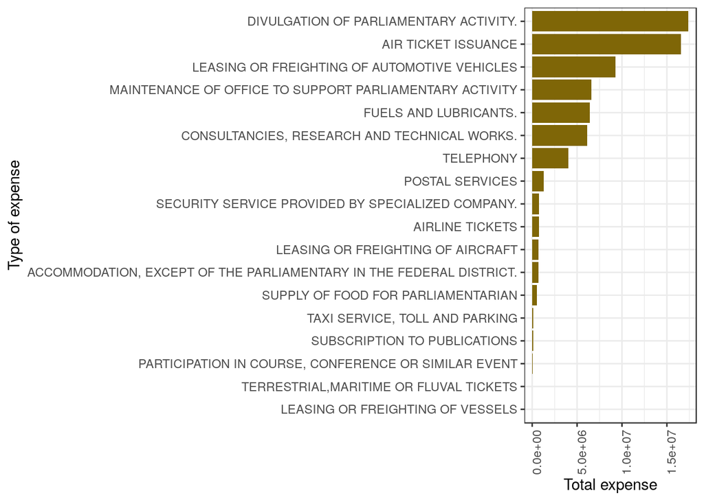

```r
data %>%
  filter(sgPartido %in% c("PMDB")) %>% # keep only PMDB
  group_by(tipoDespesa) %>%
  summarize(expense = sum(valorLíquido)) %>% # calc total expense
  ggplot(aes(reorder(tipoDespesa,expense),
             expense)) +
  geom_bar(stat="identity",
           fill="#7F6607") +
  labs(y= "Total expense",
       x="Type of expense") +
  coord_flip() +
  theme(axis.text.x = element_text(angle = 90,
                                   hjust = 1))
```

- The costlier expense for PMDB is **Divulgation of Parliamentary Activity** followed by **Air Ticket Issuance** and **Leasing or Freighting of Automotive Vehicles**.

### PT

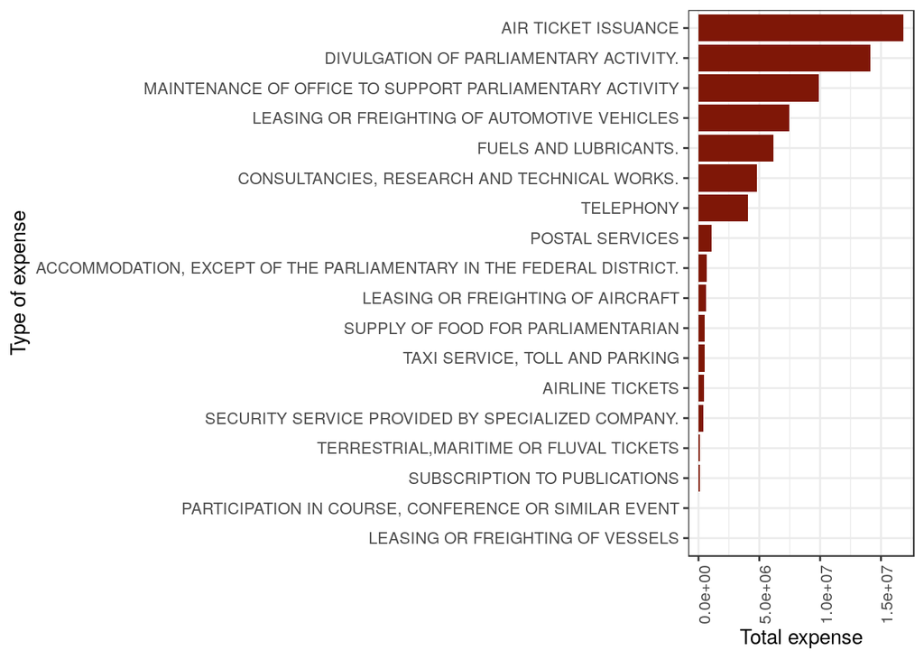

```r
data %>%
  filter(sgPartido %in% c("PT")) %>% # keep only PT
  group_by(tipoDespesa) %>%
  summarize(expense = sum(valorLíquido)) %>% # calc total expense
  ggplot(aes(reorder(tipoDespesa,expense),
             expense)) +
  geom_bar(stat="identity",
           fill="#7F1707") +
  labs(y= "Total expense",
       x="Type of expense") +
  coord_flip() +
  theme(axis.text.x = element_text(angle = 90,
                                   hjust = 1))
```

- The costlier expense for PT is **Air Ticket Issuance** followed by **Divulgation of Parliamentary Activity** and **Maintenance of Office to support Parliamentary Activity**.

### Summary

> PT and PSDB have the same three costlier expenses **Air Ticket Issuance, Divulgation and Office Maintenance**. Unlike the other for PMDB **Divulgation** is costlier than **Air Ticket Issuance** and **Vehicle Renting/Freighting** takes the spot from **Office Maintenance**.